# Stat 432 Final Project - feature

Pengyu Cheng, Bing Liang, Siyu Lai

12/6/2018

## Read data

```r
airports = read.csv("airports.csv")
airlines = read.csv("airlines.csv")
data = read.csv("flights.csv")
```

# Caveat

- During the data cleaning and visualization, we found that the data from October is missing. The reason is the IATA_CODE in this month has the format of 5 digit code while others have only three letter. So we did some search online and use the code below to solve this issue. Namely, change all the 5 digit code to 3 letters. (CITE: https://www.kaggle.com/smiller933/fixing-airport-codes/code)

```r
Airport_ID_to_IATA <- function (x) {
  df <- data.frame (ID = as.character (x), stringsAsFactors = FALSE)
  num_records = nrow (df)
  dfAirportID <- read.csv ("https://www.transtats.bts.gov/Download_Lookup.asp?Lookup=L_AIRPORT_ID",
                           colClasses=c("character", "character"),
                           col.names=c("AirportID", "Description"))
  df <- dplyr::left_join (df, dfAirportID, by=c("ID" = "AirportID"))
  dfAirport <- read.csv ("https://www.transtats.bts.gov/Download_Lookup.asp?Lookup=L_AIRPORT",
                         colClasses=c("character", "character"),
                         col.names=c("IATA_CODE", "Description"))
  dfAirport <- dfAirport [! (dfAirport$IATA_CODE %in% c('BSM', 'NYL')),]
  dfAirport = dfAirport[-which(duplicated(dfAirport$Description)),]
  df <- dplyr::left_join (df, dfAirport, by="Description")
  df$ID <- dplyr::coalesce (df$IATA_CODE, df$ID)
  return (df$ID)
}
data$ORIGIN_AIRPORT <- Airport_ID_to_IATA (data$ORIGIN_AIRPORT)
data$DESTINATION_AIRPORT <- Airport_ID_to_IATA (data$DESTINATION_AIRPORT)
```

## Subsetted Dataset (flights from JFK, LAX and ORD) & delete cancelled flights

```r
lax.idx = which(data['ORIGIN_AIRPORT'] == 'LAX')
nyc.idx = which(data['ORIGIN_AIRPORT'] == 'JFK')
ord.idx = which(data['ORIGIN_AIRPORT'] == 'ORD')
subdata = data[c(lax.idx, nyc.idx, ord.idx), ]
noncancelled.idx = which(subdata['CANCELLED'] == 0)
subdata = subdata[noncancelled.idx,]
```

# Summary statistics and data visualization:

## Visualize the airports on a map

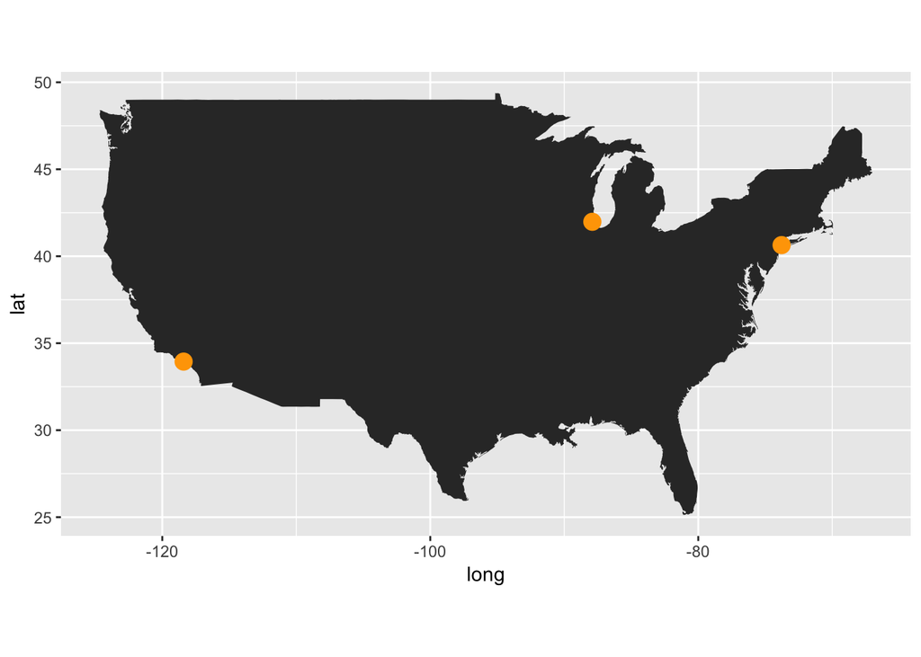

```r
library(ggplot2)
library("maps")
origin.idx = c(which(airports$IATA_CODE == 'LAX'),
               which(airports$IATA_CODE == 'JFK'),
               which(airports$IATA_CODE == 'ORD'))
origin.airports = airports[origin.idx,]
states_data = map_data("state")
labs = data.frame(
  long = origin.airports$LONGITUDE,
  lat = origin.airports$LATITUDE,
  stringsAsFactors = FALSE
  )
usa = map_data("usa")
usa_map = ggplot() + geom_polygon(data = usa, aes(x=long, y = lat, group = group)) + coord_fixed(1.3)
usa_map + geom_point(data = labs, aes(x = long, y = lat), color = "orange", size = 4)
```

## How much is the traffic of these three airports?

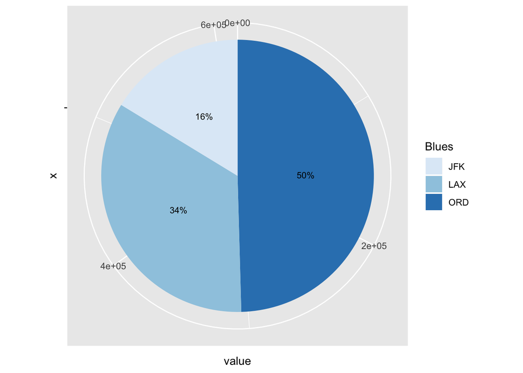

```r
df = data.frame(
  group = c("LAX", "JFK", "ORD"),
  value = c(length(which(subdata$ORIGIN_AIRPORT == 'LAX')),
            length(which(subdata$ORIGIN_AIRPORT == 'JFK')),
            length(which(subdata$ORIGIN_AIRPORT == 'ORD'))
            )
  )
pie = ggplot(df, aes(x="", y=value, fill=group))+
geom_bar(width = 1, stat = "identity") + coord_polar("y", start=0)
pie + scale_fill_brewer("Blues") + geom_text(aes(label = paste0(round(value/sum(value) *100), "%")),
              position = position_stack(vjust = 0.5), size=3)
```

- We see that the number of flights from ORD is the largest. This is reasonable as ORD is one of the most busiest airport in the world!

## Summary Statistics

```r
summary(subdata)
```

```
##       YEAR          MONTH             DAY         DAY_OF_WEEK
##  Min.   :2015   Min.   : 1.000   Min.   : 1.00   Min.   :1.000
##  1st Qu.:2015   1st Qu.: 4.000   1st Qu.: 8.00   1st Qu.:2.000
##  Median :2015   Median : 7.000   Median :16.00   Median :4.000
##  Mean   :2015   Mean   : 6.588   Mean   :15.74   Mean   :3.943
##  3rd Qu.:2015   3rd Qu.: 9.000   3rd Qu.:23.00   3rd Qu.:6.000
##  Max.   :2015   Max.   :12.000   Max.   :31.00   Max.   :7.000
##
##     AIRLINE       FLIGHT_NUMBER   TAIL_NUMBER     ORIGIN_AIRPORT
##  AA     :107299   Min.   :   1   N866AS :  1102   Length:615261
##  UA     : 97867   1st Qu.: 569   N864AS :  1037   Class :character
##  OO     : 79132   Median :1577   N869AS :  1013   Mode  :character
##  MQ     : 69526   Mean   :2164   N863AS :   993
##  DL     : 62806   3rd Qu.:3264   N868CA :   975
##  B6     : 50169   Max.   :6832   N492SW :   969
##  (Other):148462                  (Other):609172
##  DESTINATION_AIRPORT SCHEDULED_DEPARTURE DEPARTURE_TIME DEPARTURE_DELAY
##  Length:615261       Min.   :   1        Min.   :   1   Min.   : -38.00
##  Class :character    1st Qu.: 924        1st Qu.: 928   1st Qu.:  -4.00
##  Mode  :character    Median :1345        Median :1350   Median :  -1.00
##                      Mean   :1368        Mean   :1372   Mean   :  11.95
##                      3rd Qu.:1759        3rd Qu.:1809   3rd Qu.:  11.00
##                      Max.   :2359        Max.   :2400   Max.   :1492.00
##
##     TAXI_OUT        WHEELS_OFF   SCHEDULED_TIME   ELAPSED_TIME
##  Min.   :  1.00   Min.   :   1   Min.   : 40.0   Min.   : 27.0
##  1st Qu.: 13.00   1st Qu.: 946   1st Qu.: 86.0   1st Qu.: 83.0
##  Median : 17.00   Median :1407   Median :137.0   Median :133.0
##  Mean   : 19.83   Mean   :1393   Mean   :168.7   Mean   :162.8
##  3rd Qu.: 23.00   3rd Qu.:1823   3rd Qu.:240.0   3rd Qu.:232.0
##  Max.   :180.00   Max.   :2400   Max.   :718.0   Max.   :733.0
##                                                  NA's   :1592
##     AIR_TIME        DISTANCE      WHEELS_ON       TAXI_IN
##  Min.   : 13.0   Min.   :  67   Min.   :   1   Min.   :  1.000
##  1st Qu.: 58.0   1st Qu.: 337   1st Qu.:1123   1st Qu.:  4.000
##  Median :105.0   Median : 760   Median :1547   Median :  5.000
##  Mean   :136.2   Mean   :1023   Mean   :1509   Mean   :  6.798
##  3rd Qu.:204.0   3rd Qu.:1626   3rd Qu.:1953   3rd Qu.:  8.000
##  Max.   :690.0   Max.   :4983   Max.   :2400   Max.   :248.000
##  NA's   :1592                   NA's   :325    NA's   :325
```

[output cut: 9 more lines]

```
##  Min.   :0    :615261            Min.   :  0.0    Min.   :  0.0
##  1st Qu.:0   A:     0            1st Qu.:  0.0    1st Qu.:  0.0
##  Median :0   B:     0            Median :  2.0    Median :  0.0
##  Mean   :0   C:     0            Mean   : 13.5    Mean   :  0.1
##  3rd Qu.:0   D:     0            3rd Qu.: 18.0    3rd Qu.:  0.0
##  Max.   :0                       Max.   :669.0    Max.   :364.0
##                                  NA's   :480660   NA's   :480660
##  AIRLINE_DELAY    LATE_AIRCRAFT_DELAY WEATHER_DELAY
##  Min.   :   0     Min.   :  0.0       Min.   :   0.0
##  1st Qu.:   0     1st Qu.:  0.0       1st Qu.:   0.0
##  Median :   4     Median :  0.0       Median :   0.0
##  Mean   :  19     Mean   : 22.7       Mean   :   4.1
##  3rd Qu.:  21     3rd Qu.: 29.0       3rd Qu.:   0.0
##  Max.   :1480     Max.   :939.0       Max.   :1052.0
##  NA's   :480660   NA's   :480660      NA's   :480660
```

- There are many NAs in this dataset, we will delete the rows with NAs as the number of rows with NAs is relatively small, compared with the whole dataset. We will leave the NAs which are in the last 5 columns to next step. For now, we deal with the rest. We drop the rows with the NAs. Closer look into it, we found that CANCELLATION_REASON has no entry so we delete this column in the later part.

```r
subdata = subdata[-c(which(is.na(subdata$ELAPSED_TIME))), ]
nrow(subdata)
```

```
## [1] 613669
```

We have 613669 rows as of now.

## Delay Visualization

- A little dig into the data, we found that AIR_SYSTEM_DELAY + SECURITY_DELAY + AIRLINE_DELAY + LATE_AIRCRAFT_DELAY + WEATHER_DELAY = ARRIVAL_DELAY.
- AIR_SYSTEM_DELAY, SECURITY_DELAY, AIRLINE_DELAY, LATE_AIRCRAFT_DELAY, WEATHER_DELAY have many NAs. Why? It turns out that when the ARRIVAL_DEALY is less than 10, NAs will appear in these columns. We will replace NAs with 0 to indicate that the delay is not caused by any of the reasons above, and replace other values with 1 to indicate that delay was caused by one or more of the 5 reasons. (This potentially solves the dependent columns)

```r
subdata[which(is.na(subdata$AIRLINE_DELAY) == TRUE), c(27:31)] = 0
subdata[which(subdata$AIR_SYSTEM_DELAY != 0), 27] = 1
subdata[which(subdata$SECURITY_DELAY != 0), 28] = 1
subdata[which(subdata$AIRLINE_DELAY != 0), 29] = 1
subdata[which(subdata$LATE_AIRCRAFT_DELAY != 0), 30] = 1
subdata[which(subdata$WEATHER_DELAY != 0), 31] = 1
```

- How many flights are delayed? What are their proportions?

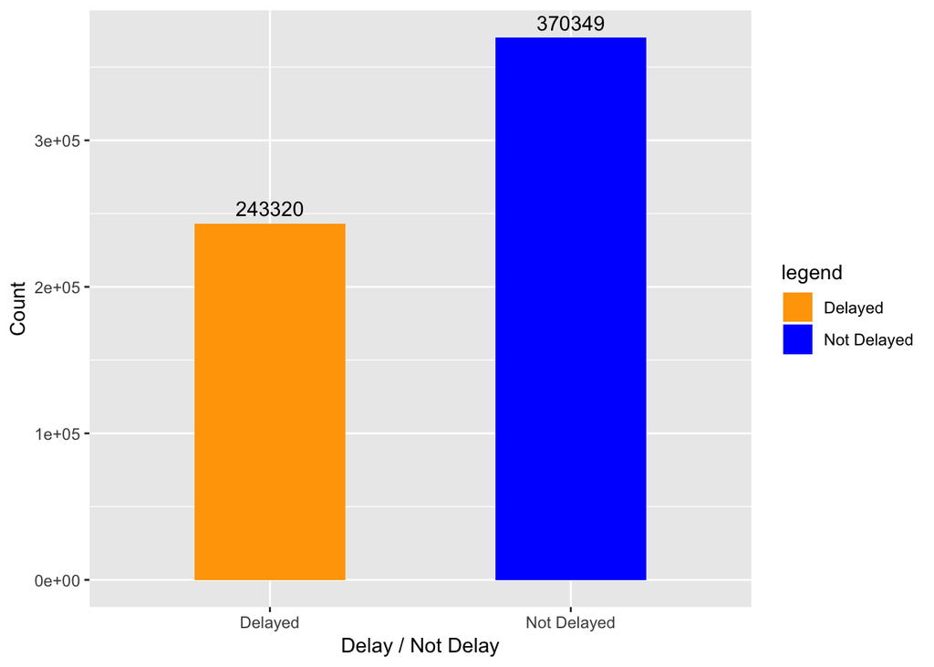

```r
flights.delay = subdata$ARRIVAL_DELAY
flights.delay[flights.delay > 0] = 'Delayed'
flights.delay[flights.delay <= 0] = "Not Delayed"
ggplot(data=as.data.frame(flights.delay), aes(flights.delay, fill = flights.delay)) + geom_bar(stat="count", width=0.5) + scale_fill_manual("legend", values = c("Delayed" = "orange", "Not Delayed" = "blue")) + geom_text(stat='count', aes(label=..count..), vjust=-0.5) + labs(x = "Delay / Not Delay", y = "Count", color = flights.delay)
```

- In our dataset, there are less delayed flights than on time filghts, which means some sampling methods will be used to deal with the dataset.
- To make it more interesting, let’s categorize the delay time into four categories:
  - Level 0: Not Delayed or somewhat delayed
  - Level 1: Slightly Delayed (less than 30 minutes)
  - Level 2: Moderately Delayed (larger than 30 minutes and less than am hour)
  - Level 3: Seriously Delayed (larger than an hour)
- Visualize the distribution of our categories

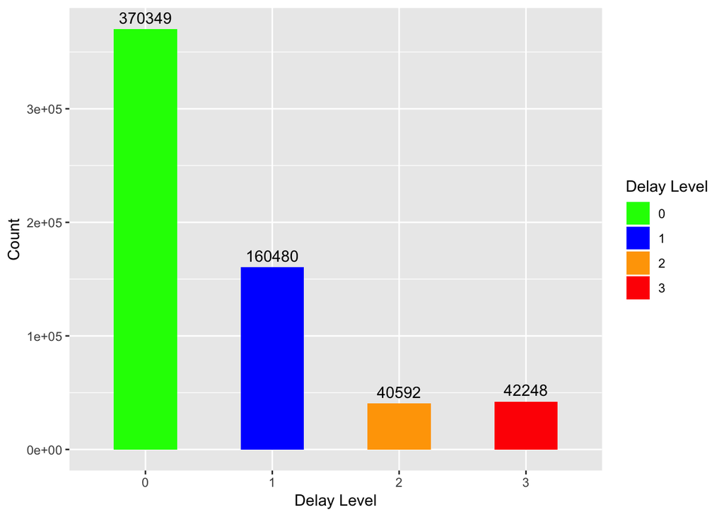

```r
subdata$ARRIVAL_DELAY_LEVEL = delay.level
ggplot(data=as.data.frame(subdata$ARRIVAL_DELAY_LEVEL), aes(subdata$ARRIVAL_DELAY_LEVEL, fill = subdata$ARRIVAL_DELAY_LEVEL)) + geom_bar(width=0.5) + scale_fill_manual("Delay Level", values = c("0" = "green", '1' = "blue", '2' = "orange", '3' = "red")) + geom_text(stat='count', aes(label=..count..), vjust=-0.5) + labs(x = "Delay Level", y = "Count", color = "Delay Level")
```

```r
nrow(subdata)
```

```
## [1] 613669
```

We see that the delay time is **imbalanced**.

- We will undersample the dataset and use the **balanced** dataset to fit classification model and regression models.
- Now let’s have a look at the bar plot for the **balanced** data.

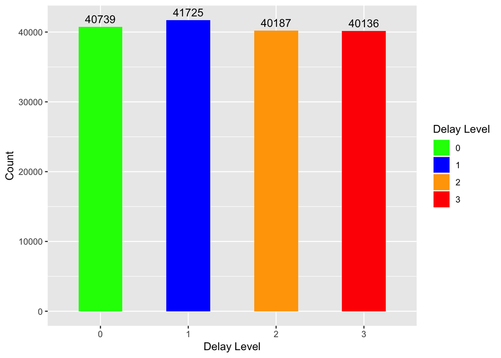

```r
ggplot(data=as.data.frame(balanced.data$ARRIVAL_DELAY_LEVEL), aes(balanced.data$ARRIVAL_DELAY_LEVEL, fill = balanced.data$ARRIVAL_DELAY_LEVEL)) + geom_bar(width=0.5) + scale_fill_manual("Delay Level", values = c("0" = "green", '1' = "blue", '2' = "orange", '3' = "red")) + geom_text(stat='count', aes(label=..count..), vjust=-0.5) + labs(x = "Delay Level", y = "Count", color = "Delay Level")
```

```r
nrow(balanced.data)
```

```
## [1] 162787
```

We still have 162787 rows. Not bad!

## Visualization of our cleaned **balanced** dataset:

- Which airlines tend to have large arrival delay times?

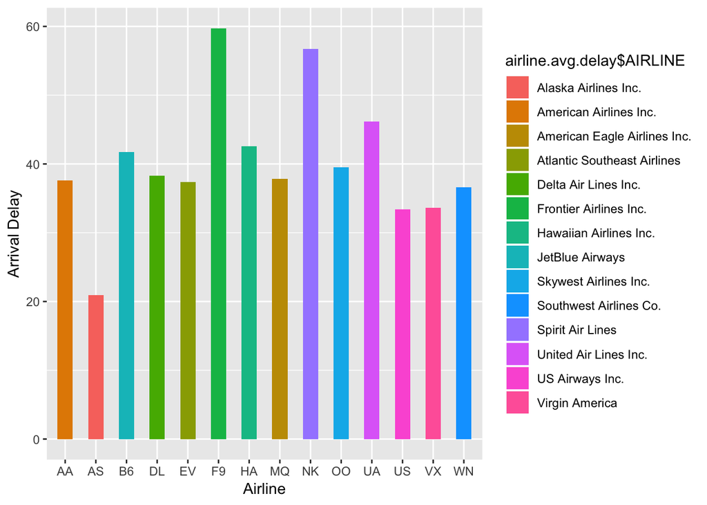

```r
airline.avg.delay = aggregate(balanced.data$ARRIVAL_DELAY, by=list(balanced.data$AIRLINE), mean)
names(airline.avg.delay) = c("Airline Code", "Mean Arrival Delay")
airline.avg.delay = merge(airline.avg.delay, airlines, by.x="Airline Code", by.y="IATA_CODE", all.x=TRUE)
ggplot(data=as.data.frame(airline.avg.delay), aes(x=airline.avg.delay$`Airline Code`, y=airline.avg.delay$`Mean Arrival Delay`, fill = airline.avg.delay$AIRLINE)) + geom_bar(stat="identity", width=0.5) + labs(x = "Airline", y = "Arrival Delay", color = "Airline")
```

- It appears we may rethink our travel plan with **Spirit Air Lines** and **Frontier Airlines**.
- Which months tend to have large arrival delay times?

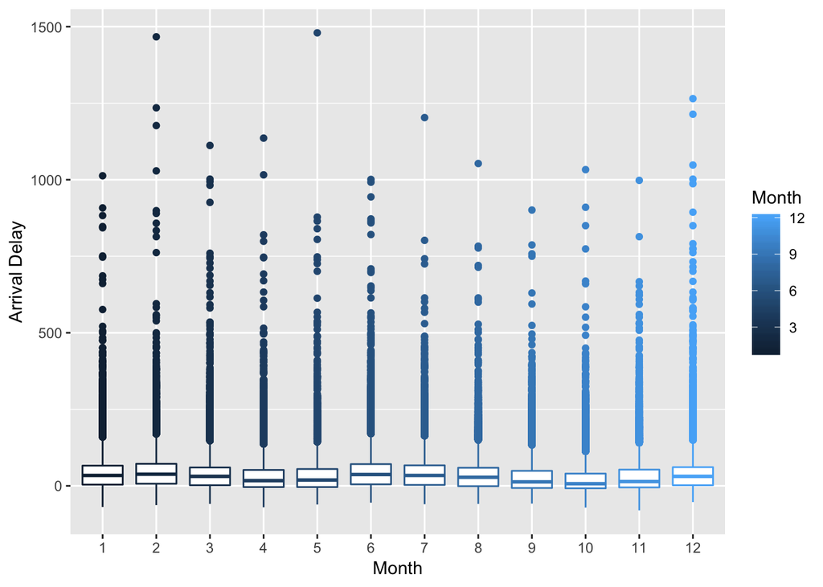

```r
x = as.factor(balanced.data$MONTH)
(p = ggplot(balanced.data, aes(x=x, y=balanced.data$ARRIVAL_DELAY, color=balanced.data$MONTH)) +
  geom_boxplot()) + labs(x = "Month", y = "Arrival Delay", color = "Month")
```

```r
outlier.idx = which(balanced.data$ARRIVAL_DELAY >= 1000)
balanced.data = balanced.data[-outlier.idx, ]
```

- Visualize mean arrival delay vs scheduled arrival time

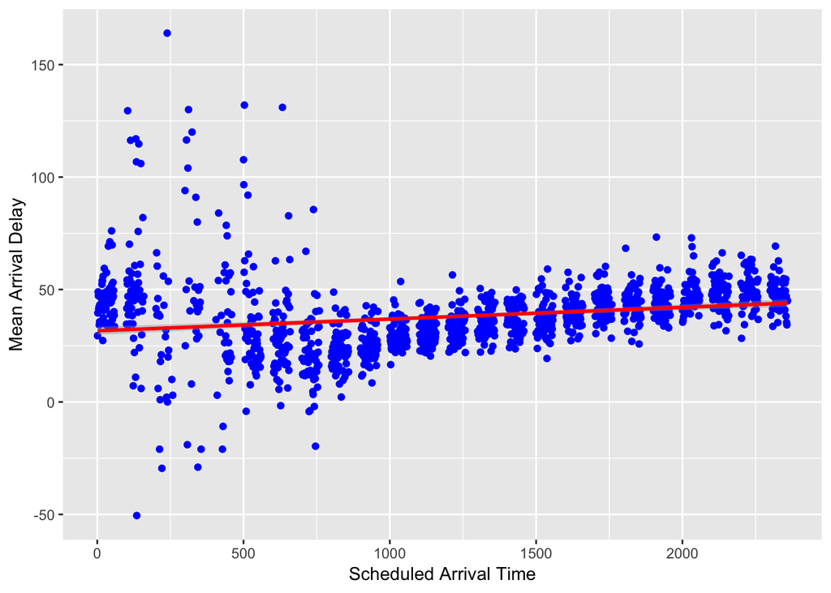

```r
hour.avg.delay = aggregate(balanced.data$ARRIVAL_DELAY, by=list(balanced.data$SCHEDULED_ARRIVAL), mean)
names(hour.avg.delay) = c("Scheduled Arrival Time", "Mean Arrival Delay")
ggplot(as.data.frame(hour.avg.delay), aes(x=hour.avg.delay$`Scheduled Arrival Time`, y=hour.avg.delay$`Mean Arrival Delay`)) + geom_point(colour = 'blue') + geom_smooth(method=lm, color ='red') + labs(x = "Scheduled Arrival Time", y = "Mean Arrival Delay")
```

- Flights with scheduled arrival time during 0:00 and 5:00 in the morning have relatively more discrete mean arrival delays and much higher chance of being arriving late. We can also see the trend in this plot that mean arrival delays increase as the day ends.
- Visualize mean arrival delay vs scheduled departure time

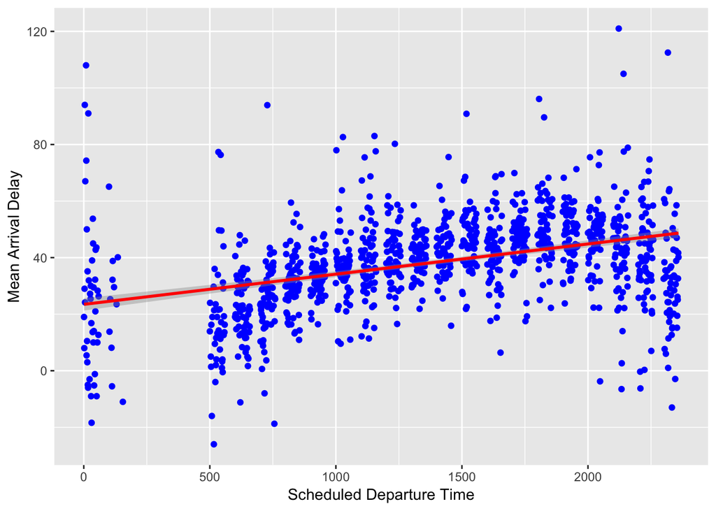

```r
hour.avg.delay = aggregate(balanced.data$ARRIVAL_DELAY, by=list(balanced.data$SCHEDULED_DEPARTURE), mean)
names(hour.avg.delay) = c("Scheduled Departure Time", "Mean Arrival Delay")
ggplot(as.data.frame(hour.avg.delay), aes(x=hour.avg.delay$`Scheduled Departure Time`, y=hour.avg.delay$`Mean Arrival Delay`)) + geom_point(colour = 'blue') + geom_smooth(method=lm, color ='red') + labs(x = "Scheduled Departure Time", y = "Mean Arrival Delay")
```

- There are almost no flights with scheduled departure time during 0:00 and 5:00. The points are not so compact compared to the previous plot which makes sense as different flight has different flight distance.

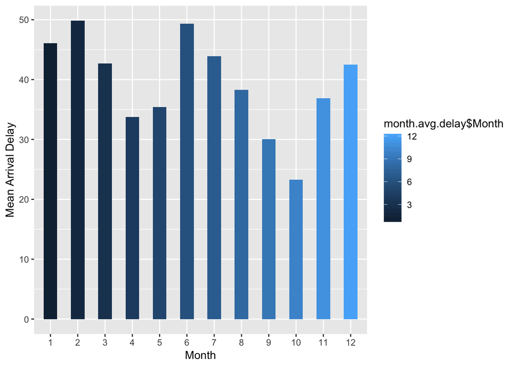

```r
month.avg.delay = aggregate(balanced.data$ARRIVAL_DELAY, by=list(balanced.data$MONTH), mean)
names(month.avg.delay) = c("Month", "Mean Arrival Delay")
ggplot(data=as.data.frame(month.avg.delay), aes(x=as.factor(month.avg.delay$Month), y=month.avg.delay$`Mean Arrival Delay`, fill = month.avg.delay$Month)) + geom_bar(stat="identity", width=0.5) + labs(x = "Month", y = "Mean Arrival Delay", color = "Month")
```

- October has the lowest mean arrival delay. Does this mean we’d better schedule our trip during this month? Or does it indicate that less people travel in October?

# Handling regression and classification data

- Closer scrutiny of our dataset and even without looking at the data, we firmly believe that the arrival delay is correlated with the departure delay. This may cause difficulty or may place us in unfair advantage if we keep this feature.

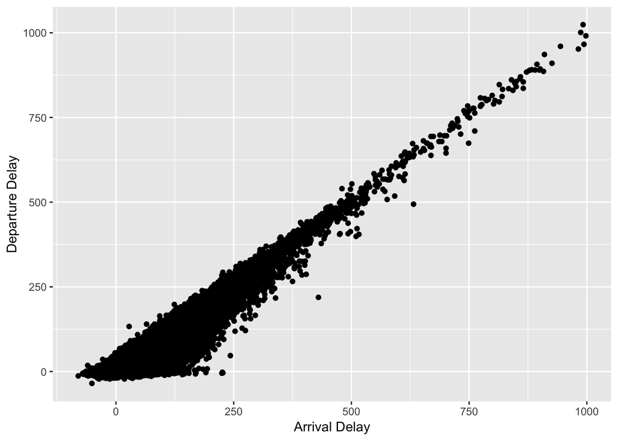

```r
ggplot(data.frame(balanced.data$ARRIVAL_DELAY, balanced.data$DEPARTURE_DELAY), aes(x =balanced.data.ARRIVAL_DELAY, y = balanced.data.DEPARTURE_DELAY)) + geom_point() + labs(x = 'Arrival Delay', y = 'Departure Delay')
```

- The plot confirms our intuition. We will remove departure delay for fairness!

```r
balanced.data = balanced.data[, -12]
```

## Split train and test set (80% and 20%)

- Entries in column CANCELLED, DIVERTED and YEAR are the same in this dataset so we remove as it will not provide any information to the model.
- CANCELLATION_REASON has no entries.
- Entries in column ARRIVAL_TIME can provide direct information on ARRIVAL_DELAY, as ARRIVAL_DELAY = ARRIVAL_TIME - SCHEDULED_ARRIVAL_TIME. If we keep this feature than there is no need to deal with the models so we drop this one.

```r
balanced.data = balanced.data[, -c(which(colnames(balanced.data) == 'DIVERTED'),
                                   which(colnames(balanced.data) == 'CANCELLED'),
                                   which(colnames(balanced.data) == 'CANCELLATION_REASON'),
                                   which(colnames(balanced.data) == 'YEAR'),
                                   which(colnames(balanced.data) == 'ARRIVAL_TIME'))]
write.csv(balanced.data, file = "BalanceData.csv",row.names=FALSE)
train.idx = sample(nrow(balanced.data), nrow(balanced.data) * 0.8)
train.data = balanced.data[train.idx,]
test.data = balanced.data[-train.idx,]
train.data = change_to_numeric(train.data)
test.data = change_to_numeric(test.data)
```

- We have 130215 rows of training data and 32554 rows of testing data.
- Data for regression:

```r
train.data.reg = data.frame(train.data[, -which(colnames(train.data) == 'ARRIVAL_DELAY_LEVEL')])
test.data.reg = data.frame(test.data[, -which(colnames(test.data) == 'ARRIVAL_DELAY_LEVEL')])
```

- Data for classification:

```r
train.data.clf = data.frame(train.data[, -which(colnames(train.data) == 'ARRIVAL_DELAY')])
test.data.clf = data.frame(test.data[, -which(colnames(test.data) == 'ARRIVAL_DELAY')])
```

## Feature Correlation:

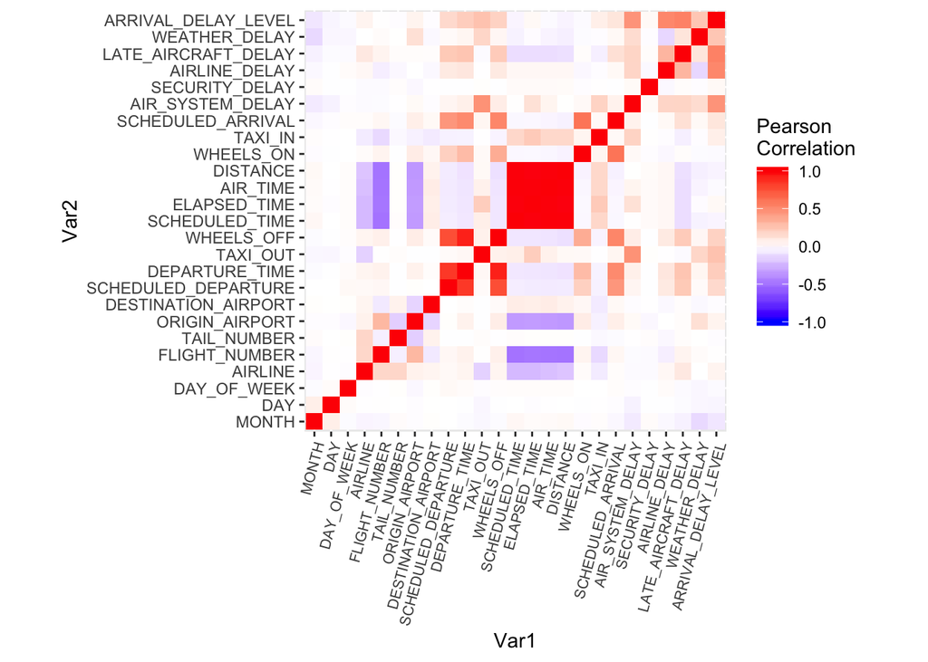

```r
library(mlbench)
library(caret)
library(reshape2)
correlationMatrix = cor(train.data.clf[,-26])
melted_cormat = melt(correlationMatrix)
ggplot(data = as.data.frame(melted_cormat), aes(x = Var1, y = Var2, fill = value)) + geom_tile() + scale_fill_gradient2(low = "blue", high = "red", mid = "white",
   midpoint = 0, limit = c(-1,1), space = "Lab",
   name="Pearson\nCorrelation") + theme(axis.text.x = element_text(angle = 75, vjust = 1, size = 8, hjust = 1)) +  coord_fixed()
```

- The plot suggests that extremely high collinearity exists in the dataset. Let’s take a closer look.

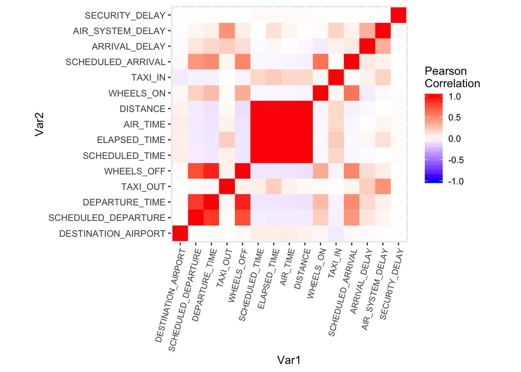

```r
correlationMatrix = cor(train.data.reg[, 8:22])
melted_cormat = melt(correlationMatrix)
ggplot(data = as.data.frame(melted_cormat), aes(x = Var1, y = Var2, fill = value)) + geom_tile() + scale_fill_gradient2(low = "blue", high = "red", mid = "white",
   midpoint = 0, limit = c(-1,1), space = "Lab",
   name="Pearson\nCorrelation") + theme(axis.text.x = element_text(angle = 75, vjust = 1, size = 8, hjust = 1)) +  coord_fixed()
```

- Amazing. We will only leave one attribute among SCHEDULED_TIME, ELAPSED_TIME, AIR_TIME and DISTANCE. We will leave DISTANCE as these four attributes are essentially the same thing (has some similar meaning). WHEELS_OFF and DEPARTURE_TIME also have large correlation. We will also drop the column WHEELS_OFF.

```r
train.data.reg = train.data.reg[, -c(12:15)]
test.data.reg = test.data.reg[, -c(12:15)]
train.data.clf = train.data.clf[, -c(12:15)]
test.data.clf = test.data.clf[, -c(12:15)]
```

## Feature Importance

- We will leave feature selection for regression task to Lasso and ridge in our third part.
- Use random forest to act as feature selection method. There are about 25 features so we choose 5 as the mtry.

```r
library(randomForest)
model = randomForest(train.data.clf[,-ncol(train.data.clf)], as.factor(train.data.clf[,ncol(train.data.clf)]), ntree = 500, mtry = 5, nodesize=15, importance = TRUE)
```

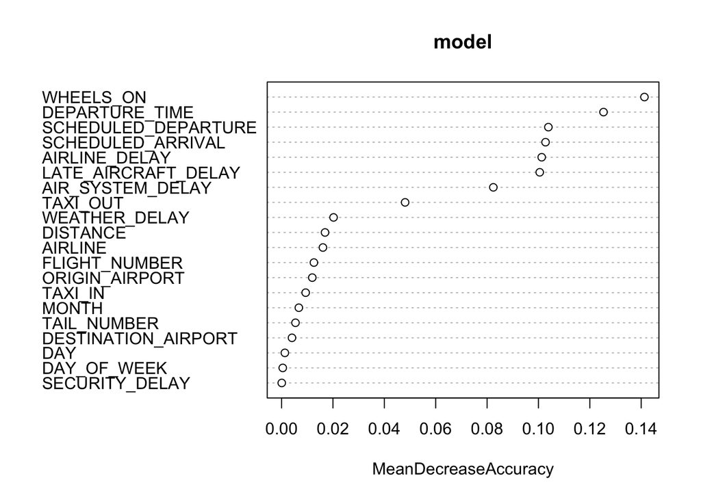

```
##                     MeanDecreaseAccuracy
## MONTH                       6.717118e-03
## DAY                         1.278364e-03
## DAY_OF_WEEK                 4.584424e-04
## AIRLINE                     1.609789e-02
## FLIGHT_NUMBER               1.258516e-02
## TAIL_NUMBER                 5.407200e-03
## ORIGIN_AIRPORT              1.194363e-02
## DESTINATION_AIRPORT         4.048991e-03
## SCHEDULED_DEPARTURE         1.038637e-01
## DEPARTURE_TIME              1.253328e-01
## TAXI_OUT                    4.808942e-02
## DISTANCE                    1.691696e-02
## WHEELS_ON                   1.412605e-01
## TAXI_IN                     9.370976e-03
## SCHEDULED_ARRIVAL           1.027587e-01
## AIR_SYSTEM_DELAY            8.243628e-02
## SECURITY_DELAY              6.183384e-05
## AIRLINE_DELAY               1.012694e-01
## LATE_AIRCRAFT_DELAY         1.004944e-01
## WEATHER_DELAY               2.022665e-02
```

```r
(importance = varImpPlot(model, scale=FALSE, type=1))
```

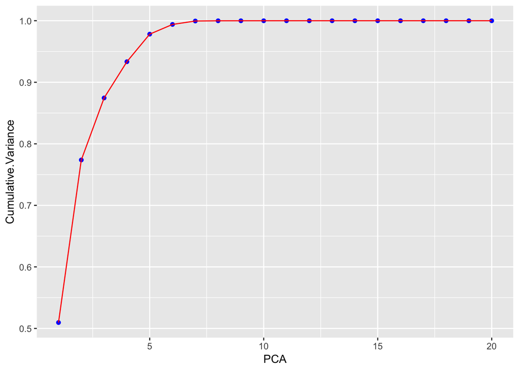

```r
library(ggfortify)
df = data.frame(train.data.clf[, -ncol(train.data.clf)])
data.pc = prcomp(df)
vars = apply(data.pc$x, 2, var)
props = vars / sum(vars)
props = data.frame(cbind(1:(ncol(train.data.clf)-1), cumsum(props)))
colnames(props) = c('PCA', 'Cumulative.Variance')
ggplot(props, aes(x=PCA, y=Cumulative.Variance)) + geom_point(color='blue') + geom_line(color='red')
```

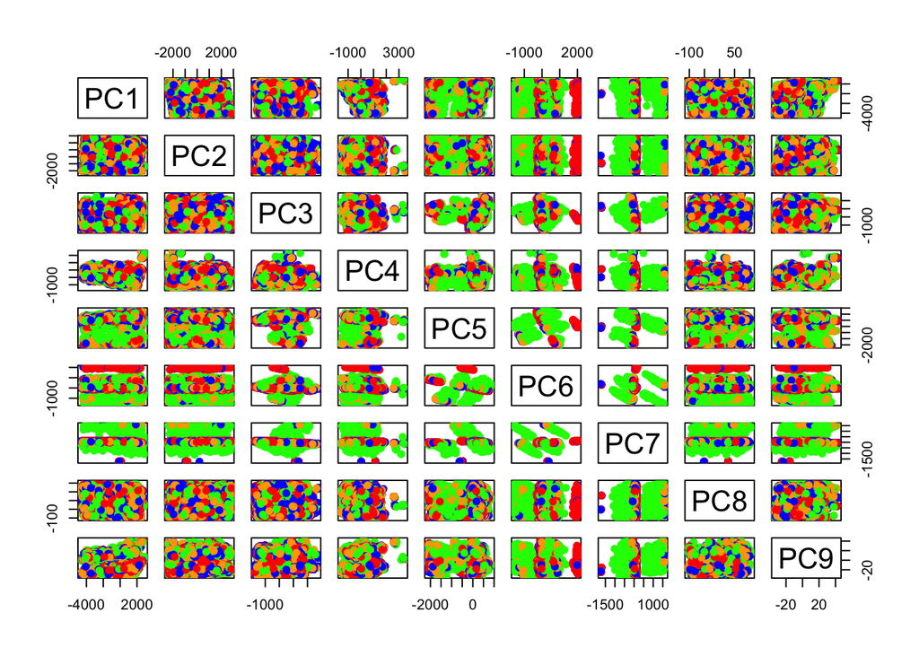

```r
pairs(data.pc$x[,1:9], col=c("red", "blue", "orange", "green")[as.factor(train.data.clf[,ncol(train.data.clf)])], pch = 19)
```

# Final Cleaned Data

- Based on the variablr importance plot and PCA, we will select the first 9 attributes as our final attributes for classification.

```r
select.idx.clf = c(which(colnames(train.data.clf) == "SCHEDULED_DEPARTURE"),
               which(colnames(train.data.clf) == "WHEELS_ON"),
               which(colnames(train.data.clf) == "WEATHER_DELAY"),
               which(colnames(train.data.clf) == "DEPARTURE_TIME"),
               which(colnames(train.data.clf) == "SCHEDULED_ARRIVAL"),
               which(colnames(train.data.clf) == "AIRLINE_DELAY"),
               which(colnames(train.data.clf) == "LATE_AIRCRAFT_DELAY"),
               which(colnames(train.data.clf) == "AIR_SYSTEM_DELAY"),
               which(colnames(train.data.clf) == "TAXI_OUT"))
train.data.clf = train.data.clf[, c(select.idx.clf, ncol(train.data.clf))]
test.data.clf = test.data.clf[, c(select.idx.clf, ncol(test.data.clf))]
```

## Write final data for classification into csv file

```r
write.csv(train.data.clf, file = "TrainData_clf.csv",row.names=FALSE)
write.csv(test.data.clf, file = "TestData_clf.csv",row.names=FALSE)
```

- Our cleaned data for classifcation:
  - training data: 130215 rows, 10 columns (including response variable)
  - test data: 32554 rows, 10 columns (including response variable)

## Write final data for regression into csv file

```r
write.csv(train.data.reg, file = "TrainData_reg.csv",row.names=FALSE)
write.csv(test.data.reg, file = "TestData_reg.csv",row.names=FALSE)
```

- Our cleaned data for regression:
  - training data: 130215 rows, 21 columns (including response variable)
  - test data: 32554 rows, 21 columns (including response variable)